# Notebook

## Filters

We will answer these quesions:

1. What are filters?
2. How to build one?
3. What has `convolution` operation to do with filters?

A filter $f$ is a function that takes an input signal and gives an ouput signal.

$f: x[n] \to y[n]$

In general filter means to get rid of some of the components from a mix. Think of filters as special functions that are able to separate these components from a mix.

A digital signal is an array of numbers so what does it even mean to filter them? Are they made of some components that we can filter?

According to **Fourier**, any signal can be broken into **weighted sum of sinusoids at different frequencies**. So, filtering can mean to get rid of some of these components. But now the question is how can we do that?

# Experiment

Let say I have a signal that is a mix of two sinusoids at freq $f_1$ and $f_2$. Now my task is to filter out $f_1$ component from the signal. Let's make an attempt to do this.

```python
import numpy as np
import modusa as ms
```

```python
# Creating a signal by mixing two frequency components
sr = 500 # Hz
f1 = 10 # Hz
f2 = 15 # Hz
t = np.arange(2*sr) / sr
y1 = np.sin(2*np.pi*f1*t)
y2 = np.sin(2*np.pi*f2*t)
y3 = y1 + y2
```

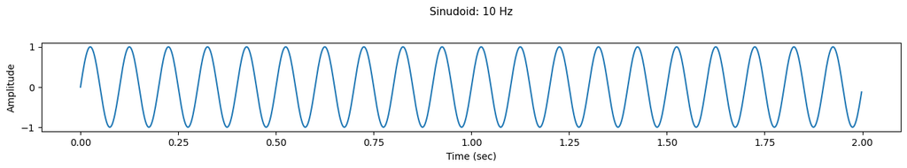

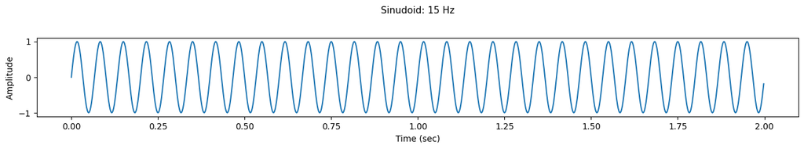

[figure not shown]

```python
display(ms.plot1d(
    (y1, t),
    title=f"Sinudoid: {f1} Hz",
    xlabel="Time (sec)",
    ylabel="Amplitude"
))

display(ms.plot1d(
    (y2, t),
    title=f"Sinudoid: {f2} Hz",
    xlabel="Time (sec)",
    ylabel="Amplitude"
))

display(ms.plot1d(
    (y3, t),
    title=f"Sinudoid: {f1} and {f2} Hz components",
    xlabel="Time (sec)",
    ylabel="Amplitude"
))
```

```python
# Let us stack these signal into 1
mix_y = np.concatenate((y1, y2, y3))
mix_t = np.arange(mix_y.size) / sr
```

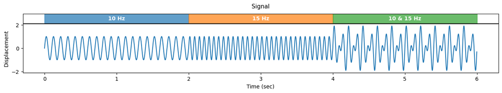

```python
ms.plot1d(
    (mix_y, mix_t),
    ann=[(0, 2, f"{f1} Hz"), (2, 4, f"{f2} Hz"), (4, 6, f"{f1} & {f2} Hz")],
    title="Signal",
    xlabel="Time (sec)",
    ylabel="Displacement",
)
```

```python
ref = np.sin(2*np.pi*f1*mix_t)
```

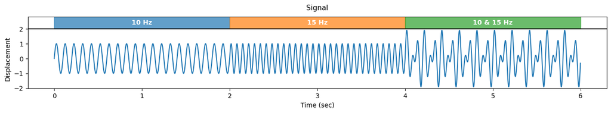

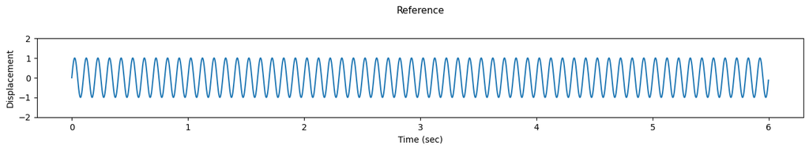

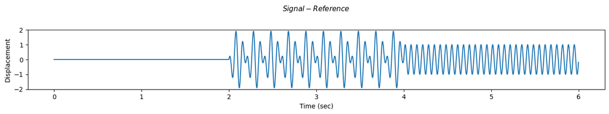

```python
display(ms.plot1d(
    (mix_y, mix_t),
    ann=[(0, 2, f"{f1} Hz"), (2, 4, f"{f2} Hz"), (4, 6, f"{f1} & {f2} Hz")],
    title="Signal",
    xlabel="Time (sec)",
    ylabel="Displacement",
    ylim=(-2, 2),
))

display(ms.plot1d(
    (ref, mix_t),
    title="Reference",
    xlabel="Time (sec)",
    ylabel="Displacement",
    ylim=(-2, 2),
))

display(ms.plot1d(
    (mix_y - ref, mix_t),
    title="$Signal - Reference$",
    xlabel="Time (sec)",
    ylabel="Displacement",
    ylim=(-2, 2),
))
```

In order to gain further insight on filters, I am looking at "https://www.dspguide.com/ch14/1.htm"

The page mentions about three characterstics of a filter.

- Impulse response
- Step response
- Frequency response

```python
imp = np.array([1])
h = np.array([1/3, 1/2, 1/2])
np.convolve(imp, h)
```

```
array([0.33333333, 0.5       , 0.5       ])
```